# Supplemental Script from J. Proteome Res. article

Kai-Ting Fan and Aaron Rendahl

2017-07-18

This vignette contains the code the supplemental script from the J. Proteome Res. article ([DOI:10.1021/acs.jproteome.5b00772](http://doi.org/10.1021/acs.jproteome.5b00772)). After the ProteinTurnover package is installed, the location of the script can be found using the `system.file` command.

```r
system.file(package="ProteinTurnover", "extscripts", "JProteomeRes_Supplemental.R")
```

It could be copied to the current directory from with R using `file.copy`.

```r
f <- system.file(package="ProteinTurnover", "extscripts", "JProteomeRes_Supplemental.R")
file.copy(f, ".")
```

Sample data and results used in this vignette are currently (15 Jul 2017) available here: http://users.stat.umn.edu/~rend0020/ProteinTurnoverScript.

## SECTION 1: Install R packages

Install package “ProteinTurnover” and other required packages. R-3.2.0 or higher is required.

To access mzXML files, the package “xcms” from Bioconductor is also required. For installation:

```r
source("http://bioconductor.org/biocLite.R")
biocLite("xcms")
```

The ProteinTurnover package is available on GitHub, https://github.com/HegemanLab/ProteinTurnover.

```r
devtools::install_github("HegemanLab/ProteinTurnover")
```

For reference, check the version that’s installed

```r
R.version.string
# [1] "R version 3.3.2 (2016-10-31)"
packageVersion("ProteinTurnover")
# [1] '1.1.1'
```

## SECTION 2: Prepare data files

- All MS data files were converted from .RAW to .mzXML files.
- Peptide identification file was exported from Scaffold spectrum report and saved as .csv file.
- This .csv file needs to contain peptide retention time in column “Spectrum name” following this format “Elution: xx min”.
- Please also refer Supporting Information Table S-3 for the required column headers in the .csv file.
- All data files should be placed in the same data directory.

## SECTION 3: Run ProteinTurnover

Load library.

```r
library(ProteinTurnover)
```

Set up list to hold parameters for this run.

```r
p <- list()
```

Set the number of cores to use. On Windows OS, this should be 1; on Linux, it can be set as appropriate for your system.

```r
p$num.cores <- 1
```

Set directories and scaffold file name.

- Set the data file directory.
- Set the directory that result files should be stored in.
- Set scaffold file, which should be store in the data directory.

Note: These are treated as relative to the current directory, unless you give a complete path. For Windows OS users, to use subdirectories, replace all the with \ from the copy of directory path.

This is an example data directory:

```r
p$dir.data <- "mzs"
```

This is an example result directory:

```r
p$dir.results <- "Turnover"
```

This is an example peptide file:

```r
p$scaffoldfile <- "soluble.csv"
```

Set times and corresponding file names:

- Set times as the labeling time points.
- set names of mzXML files that correspond to the above time points.
- set names of rds (R data files) that correspond to the above times.
- In this example, mzXML files in the data directory are named as hr_0.mzXML, hr_8.mzXML, etc. by users.
- Note: R is case sensitive, including the file extension name.

```r
p$times <- c(0,4,8,16,24,32,40,48)
p$rawfiles <- paste0("hr_", p$times, ".mzXML")
p$rdsfiles <- paste0("hr_", p$times, ".rds")
```

Set parameters for use in the fit.

- The confidence level is based on the peptide identification confidence value.
- m/z windows set as plus or minus 0.005
- Retention time window set as plus or minus 30 sec
- Add extra 5 isotopic channels

```r
p$isotope <- "N"
p$confidence.level <- 80
p$time.zero <- 0
p$time.unit <- "Hour"
p$mz.tol <- 0.005
p$rt.tol <- 30
p$extra.channels <- 5
```

Set parameter to get the relative abundance from EIC (relAbForTimes). Available options are (“lm”, “rlm”, “lqs”, “rq”, “sum”,“log”).

```r
p$regression.model <- "lm"   # "lm" as linear regression
```

Set up parameters for fitting. Options are “incorporation” for stable isotope label incorporation and “dilution” for label dilution

```r
p$isotope.method <- "incorporation"
```

Set up betabinomial options for the “M” parameter in Eq.(5). Available options are (“none”, “one”, “many”). If users choose “none”, then the binomial model will be used

```r
p$M.model <- "one"
```

Set the alpha parameters, Eq.(6). For incorporation, available options are (“many”, “k”, “kplateau”, or “log2k”). For dilution, available options are (“one”, “many”). “many” always means the algorithm will fit a different value of that parameter for each time point.

```r
p$alpha.model <- "log2k"     #make log2 value of turnover rate k
```

```r
p$plim <- NA
```

### Create results directory

This will give warning if already exists.

```r
dir.create(p$dir.results)
```

### Convert raw mzXML files to Rdata files

This only need be done once. This speeds up the steps below; it can be skipped if the raw files are used in addEICs.

```r
rawToRDS(p$dir.data, p$rawfiles, p$rdsfiles)
# reading hr_0.mzXML (time: 1m 38.3s)
# writing hr_0.rds (time: 53.2s)
# reading hr_4.mzXML (time: 1m 39.7s)
# writing hr_4.rds (time: 54.2s)
# reading hr_8.mzXML (time: 1m 49.0s)
# writing hr_8.rds (time: 56.9s)
# reading hr_16.mzXML (time: 1m 19.1s)
# writing hr_16.rds (time: 41.9s)
# reading hr_24.mzXML (time: 1m 42.0s)
# writing hr_24.rds (time: 56.3s)
# reading hr_32.mzXML (time: 1m 41.6s)
# writing hr_32.rds (time: 56.4s)
# reading hr_40.mzXML (time: 1m 42.0s)
# writing hr_40.rds (time: 56.6s)
# reading hr_48.mzXML (time: 1m 46.8s)
# writing hr_48.rds (time: 53.6s)
# Warning message:
# 'loadRcppModules' is deprecated.
# Use 'loadModule' instead.
# See help("Deprecated")
```

The warning message is from a dependent package; it doesn’t cause any problems at this point.

### Read in all the data

Read the scaffold file.

```r
dat <- readScaffoldFile(p$scaffoldfile, times=p$times, dir=p$dir.data)
# reading Scaffold file ...
# read soluble.csv
```

Prepare the data structure for each sequence.

```r
seqs <- makeSequences(dat,
                      isotope=p$isotope,
                      confidence=p$confidence.level,
                      time.zero=p$time.zero,
                      time.unit=p$time.unit,
                      mz.tol=p$mz.tol,
                      rt.tol=p$rt.tol,
                      extra.channels=p$extra.channels)
# finding Sequences ...
```

Get the EIC data for each sequence.

```r
seqs <- addEICs(seqs, files=p$rdsfiles, type="rds", times=p$times, dir=p$dir.data)
# reading hr_0.rds (time: 27.0s)
# adding EICs for Time 0 (time: 4.5s)
# reading hr_4.rds (time: 27.4s)
# adding EICs for Time 4 (time: 3.7s)
# reading hr_8.rds (time: 28.9s)
# adding EICs for Time 8 (time: 2.9s)
# reading hr_16.rds (time: 21.0s)
# adding EICs for Time 16 (time: 2.2s)
# reading hr_24.rds (time: 28.3s)
# adding EICs for Time 24 (time: 2.5s)
# reading hr_32.rds (time: 3.2s)
# adding EICs for Time 32 (time: 2.0s)
# reading hr_40.rds (time: 3.2s)
# adding EICs for Time 40 (time: 1.7s)
# reading hr_48.rds (time: 28.6s)
# adding EICs for Time 48 (time: 1.8s)
```

Save what we’ve done so far.

```r
save(dat, seqs, p, file=file.path(p$dir.results, "eicdata.Rdata"))
```

### Get fits for each sequence

Reload what we’ve done so far. Skip these two command lines if users just run the above code

```r
dir.results <- "Turnover"
load(file.path(dir.results, "eicdata.Rdata"))
```

Set up multiple cores.

```r
if(!is.null(p$num.cores)) { options(mc.cores=p$num.cores) }
```

Get the distribution abundance proportion and fit for each sequence. mclapply.progress is just like lapply except works in parallel and shows progress. makeRelAb is a wrapper for relAbForTimes, to handle any error. makeFit is a wrapper for pepfit, to handle any error.

The algorithm chooses parameters that make the smallest difference between the observed proportion for each isotopic channel to the predicted proportion. In makeFit, if users prefer using relative abundance instead of proportion (the current default setting) for any reason, they can add “useRelAb=TRUE” as a new parameter. Across time points, the proportionality constant differs, so using relative abundance gives more weight to the time points with higher total values of relative abundance. Using proportions will treat each time point equally.

```r
seqs <- mclapply.progress(seqs, function(seq) {
  relAb <- makeRelAb(seq, regression.model=p$regression.model)
  fit <- makeFit(seq=seq, relAb=relAb, M=p$M.model, alpha=p$alpha.model, se=TRUE, isotope.method=p$isotope.method)
  list(seq=seq, relAb=relAb, fit=fit)
})
# Processing 1854 items, in parallel on 8 cores
# Started Sat Jul 15 16:03:51 2017
# ================================================================================
# Ended   Sat Jul 15 16:06:08 2017; elapsed time: 2m 17.0s
```

Save results so far.

```r
save(dat, seqs, p, file=file.path(p$dir.results, "fit-log2k.Rdata"))
```

### Get parameters and save to a file

Load results. Skip these two command lines if users just run the above code.

```r
dir.results <- "Turnover"
load(file.path(dir.results, "fit-log2k.Rdata"))
```

Get the parameter fits for those succeeded and write to file.

```r
fits <- getPars(seqs)
# There were 50 or more warnings (use warnings() to see the first 50)
write.csv(fits, file=file.path(p$dir.results, "fits-log2k.csv"), na="")
```

The warnings in this case are all `In sqrt(diag(s$fit$vcov)) : NaNs produced`; that means that it could not compute a standard deviation for at least one of the parameters for that fit.

### Make HTML output for each seq

Load what we’ve done so far. Skip these two command lines if users just run the above code.

```r
dir.results <- "Turnover"
load(file.path(dir.results, "fit-log2k.Rdata"))
```

Set up multiple cores.

```r
if(!is.null(p$num.cores)) { options(mc.cores=p$num.cores) }
```

Make the output.

```r
out <- makeSequenceHTML(seqs, dir=p$dir.results, file="results-log2k")
# Creating output for sequences with errors (these are faster).
# Processing 866 items, in parallel on 8 cores
# Started Sat Jul 15 16:06:20 2017
# ================================================================================
# Ended   Sat Jul 15 16:06:55 2017; elapsed time: 35.0s
# Creating output for sequences without errors.
# Processing 988 items, in parallel on 8 cores
# Started Sat Jul 15 16:06:55 2017
# ================================================================================
# Ended   Sat Jul 15 16:19:49 2017; elapsed time: 12m 54.0s
# There were 50 or more warnings (use warnings() to see the first 50)
```

The warnings here are agin `In sqrt(diag(s$fit$vcov)) : NaNs produced`.

Results are currently (15 Jul 2017) available here: http://users.stat.umn.edu/~rend0020/ProteinTurnoverScript/Turnover/results-log2k.html

## SECTION 4: Explore each peptide’s fit as desired

Load saved result.

```r
dir.results <- "Turnover"
load(file.path(dir.results, "fit-log2k.Rdata"))
```

Pick a fit to explore. Put the index number of whichever peptide you want to explore, eg. No.2 peptide in the output file.

```r
s <- seqs[[2]]
```

Get usual output for the fit.

```r
s$fit
```

[output not shown]

```r
score.visual(s$fit)
```

```
## Overall: 82.6
##  Time  0: 87.9
##  Time  4: 90.9
##  Time  8: 71.9
##  Time 16: 79.8
```

Make desired pictures for this No.2 peptide:

Make regression plots:

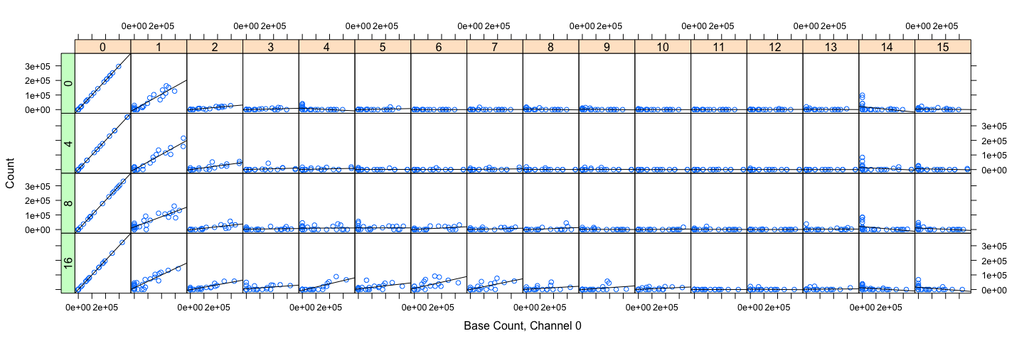

```r
regressionPlot(s$relAb)
```

Make eic plots:

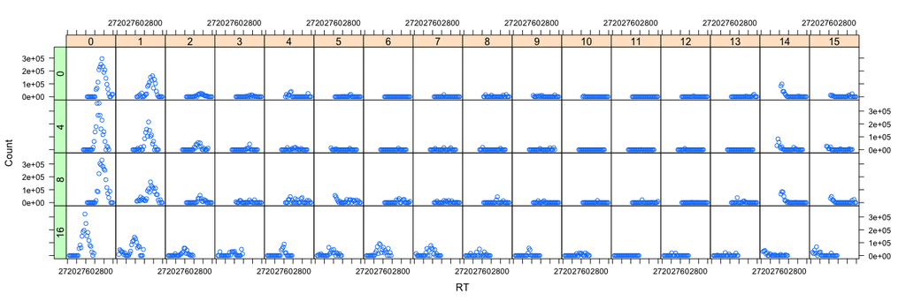

```r
plot(s$relAb)
```

Make MLE plots:

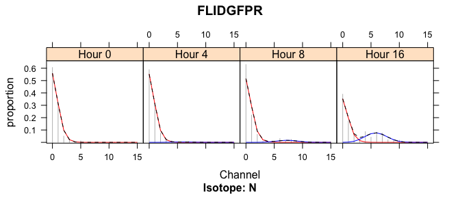

```r
plot(s$fit)
```

## SECTION 5: Use alpha model as “many” instead

Load saved EIC data.

```r
dir.results <- "Turnover"
load(file.path(dir.results, "eicdata.Rdata"))
```

Set alpha model differently.

```r
p$alpha.model <- "many"
```

Set up multiple cores.

```r
if(!is.null(p$num.cores)) { options(mc.cores=p$num.cores) }
```

Get the distribution abundance proportion, fit, and curve for each sequence.

```r
seqs <- mclapply.progress(seqs, function(seq) {
  relAb <- makeRelAb(seq, regression.model=p$regression.model)
  fit <- makeFit(seq=seq, relAb=relAb, M=p$M.model, alpha=p$alpha.model, se=TRUE, isotope.method=p$isotope.method)
  list(seq=seq, relAb=relAb, fit=fit)
  curve <- makeCurve(fit, plim=p$plim, isotope.method=p$isotope.method)
  list(seq=seq, relAb=relAb, fit=fit, curve=curve)
})
# Processing 1854 items, in parallel on 8 cores
# Started Sat Jul 15 16:20:01 2017
# ================================================================================
# Ended   Sat Jul 15 16:23:44 2017; elapsed time: 3m 43.0s
```

Save results so far.

```r
save(dat, seqs, p, file=file.path(p$dir.results, "fit-many.Rdata"))
```

Get the parameter fits for those succeeded and write to file.

```r
fits <- getPars(seqs)
# There were 50 or more warnings (use warnings() to see the first 50)
write.csv(fits, file=file.path(p$dir.results, "fits-many.csv"), na="")
```

Output to HTML:

```r
out <- makeSequenceHTML(seqs, dir=p$dir.results, file="results-many")
# Creating output for sequences with errors (these are faster).
# Processing 853 items, in parallel on 8 cores
# Started Sat Jul 15 16:23:55 2017
# ================================================================================
# Ended   Sat Jul 15 16:24:13 2017; elapsed time: 18.0s
# Creating output for sequences without errors.
# Processing 1001 items, in parallel on 8 cores
# Started Sat Jul 15 16:24:13 2017
# ================================================================================
# Ended   Sat Jul 15 16:38:23 2017; elapsed time: 14m 10.0s
# There were 50 or more warnings (use warnings() to see the first 50)
```

We’ll compare some of the output.

```r
s <- seqs[[2]]
```

```r
options(width=100)
s$fit
```

```
##
## Parameter Estimates:
##            Estimate   Std. Error
## alpha4    0.9869992    0.1511146
## alpha8    0.9222995    0.2706539
## alpha16   0.6300262    0.5167168
## pi4       0.4774098    2.2855371
## pi8       0.6093767    0.6272167
## pi16      0.4884376    0.3229856
## M       124.2328584 5097.4984384
##
## Estimated Correlations:
##              alpha4      alpha8     alpha16         pi4         pi8       pi16          M
## alpha4  1.000000000 0.002081881 0.012688412 0.489184159 0.005092920 0.01527479 0.07253672
## alpha8  0.002081881 1.000000000 0.005020503 0.002786635 0.042963163 0.00604387 0.02870106
## alpha16 0.012688412 0.005020503 1.000000000 0.016983667 0.012281693 0.16940526 0.17492398
## pi4     0.489184159 0.002786635 0.016983667 1.000000000 0.006816965 0.02044557 0.09709170
## pi8     0.005092920 0.042963163 0.012281693 0.006816965 1.000000000 0.01478516 0.07021161
## pi16    0.015274786 0.006043870 0.169405265 0.020445574 0.014785163 1.00000000 0.21058003
## M       0.072536724 0.028701058 0.174923976 0.097091703 0.070211608 0.21058003 1.00000000
##
## Fitted Deviance: 0.42, with 57 df
##   Null Deviance: 12.06, with 60 df
## X2 = 80646, sigma2 = 1414.8, R2 = 0.96825
##
## Time Elapsed: 0.8s
```

```r
score.visual(s$fit)
```

```
## Overall: 82.6
##  Time  0: 87.9
##  Time  4: 90.9
##  Time  8: 71.9
##  Time 16: 79.8
```

Make MLE plots:

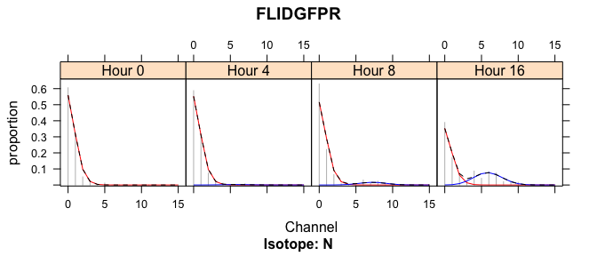

```r
plot(s$fit)
```

Make the plot of non-linear regression curve.

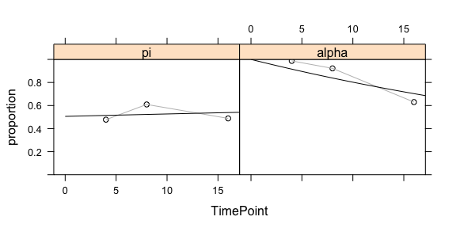

```r
plot(s$curve)
```